# GLMs and GAMs Rmarkdown script

# Example: Ozone Levels (need data file: ozone.data.txt)

- Want to model ozone concentration as a function of three continuous explanatory variables.

```r
library(readxl)
data_ozone_xls <- read_excel("D:/Udemy/Linear Regression GLMs and GAMs with R/data files/data.ozone.xls.xlsx")
ozone.data <- as.data.frame(data_ozone_xls)
head(ozone.data, 5)
```

```
##   rad temp wind ozone
## 1 190   67  7.4    41
## 2 118   72  8.0    36
## 3 149   74 12.6    12
## 4 313   62 11.5    18
## 5 299   65  8.6    23
```

```r
attach(ozone.data)
names(ozone.data)
```

```
## [1] "rad"   "temp"  "wind"  "ozone"
```

```r
str(ozone.data)
```

```
## 'data.frame':    111 obs. of  4 variables:
##  $ rad  : num  190 118 149 313 299 99 19 256 290 274 ...
##  $ temp : num  67 72 74 62 65 59 61 69 66 68 ...
##  $ wind : num  7.4 8 12.6 11.5 8.6 13.8 20.1 9.7 9.2 10.9 ...
##  $ ozone: num  41 36 12 18 23 19 8 16 11 14 ...
```

#### Generalized Additive Models (GAMs) provide nonparametric smoothing.

#### They allow you to view the shape of the relationship, without prejudging

#### See Wikipedia http://en.wikipedia.org/wiki/Generalized_additive_mode

# first remove prvious variables foating around in your workspace

```r
# rm(list - ls()) # remove previous variables
ls()
```

```
##  [1] "a1"             "b4"             "data_ozone_xls" "df"
##  [5] "df2"            "female"         "male"           "mod.0"
##  [9] "mod.1"          "n"              "ozone.data"     "TAB"
## [13] "test1"          "x"              "y"              "z"
```

```r
search() # the search command returns the data-sets and the packages
```

```
##  [1] ".GlobalEnv"        "ozone.data"        "package:readxl"
##  [4] "package:mgcv"      "package:nlme"      "package:epiR"
##  [7] "package:survival"  "package:stats"     "package:graphics"
## [10] "package:grDevices" "package:utils"     "package:datasets"
## [13] "package:methods"   "Autoloads"         "package:base"
```

```r
# that are floating around in your workspace
```

```r
head(ozone.data)
```

```
##   rad temp wind ozone
## 1 190   67  7.4    41
## 2 118   72  8.0    36
## 3 149   74 12.6    12
## 4 313   62 11.5    18
## 5 299   65  8.6    23
## 6  99   59 13.8    19
```

```r
ozone.data <- as.data.frame(ozone.data)
```

## Examine all the bivariate plots fitting a non-parametric smoothed lowess line

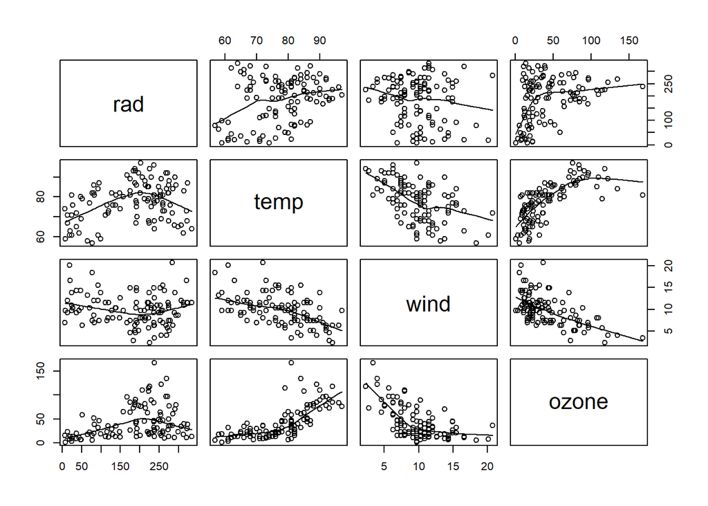

```r
pairs (ozone.data, panel=function(x,y){points(x,y);lines(lowess(x,y))})
```

## we will need to use Wood’s GAM package mgcv:

```r
library(mgcv)
```

## fit all three explanatory variables using a non-parametric smoother s():

```r
m1=gam(ozone~s(rad)+s(temp)+s(wind))
```

# View the results:

```r
summary(m1)
```

```
##
## Family: gaussian
## Link function: identity
##
## Formula:
## ozone ~ s(rad) + s(temp) + s(wind)
##
## Parametric coefficients:
##             Estimate Std. Error t value Pr(>|t|)
## (Intercept)    42.10       1.66   25.36   <2e-16 ***
## ---
## Signif. codes:  0 '***' 0.001 '**' 0.01 '*' 0.05 '.' 0.1 ' ' 1
##
## Approximate significance of smooth terms:
##           edf Ref.df      F p-value
## s(rad)  2.763  3.451  3.964 0.00859 **
## s(temp) 3.841  4.762 11.612 < 2e-16 ***
## s(wind) 2.918  3.666 13.770 < 2e-16 ***
## ---
## Signif. codes:  0 '***' 0.001 '**' 0.01 '*' 0.05 '.' 0.1 ' ' 1
##
## R-sq.(adj) =  0.724   Deviance explained = 74.8%
## GCV =    338  Scale est. = 305.96    n = 111
```

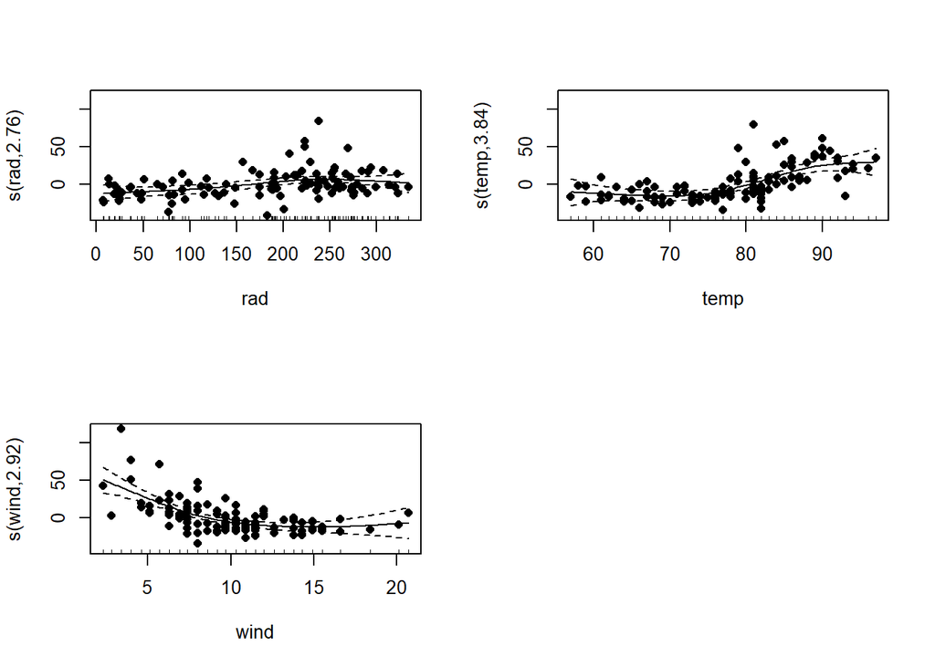

```r
par(mfrow=c(2,2))
plot(m1,residuals=T,pch=16)
```

## Note that intercept is parametric coefficient but ## all explanatory variables are fitted as smooth terms. ## All explanatory variables are significant, but radiation is least significant ## So, we fit a second model, omitting radiation:

```r
m2=gam(ozone~(temp) + s(wind))
summary(m2) # without s(rad)
```

```
##
## Family: gaussian
## Link function: identity
##
## Formula:
## ozone ~ (temp) + s(wind)
##
## Parametric coefficients:
##             Estimate Std. Error t value Pr(>|t|)
## (Intercept) -84.2626    17.9757  -4.688 8.28e-06 ***
## temp          1.6243     0.2299   7.067 1.76e-10 ***
## ---
## Signif. codes:  0 '***' 0.001 '**' 0.01 '*' 0.05 '.' 0.1 ' ' 1
##
## Approximate significance of smooth terms:
##           edf Ref.df    F p-value
## s(wind) 3.238   4.05 13.9  <2e-16 ***
## ---
## Signif. codes:  0 '***' 0.001 '**' 0.01 '*' 0.05 '.' 0.1 ' ' 1
##
## R-sq.(adj) =   0.66   Deviance explained = 67.3%
## GCV = 395.57  Scale est. = 376.91    n = 111
```

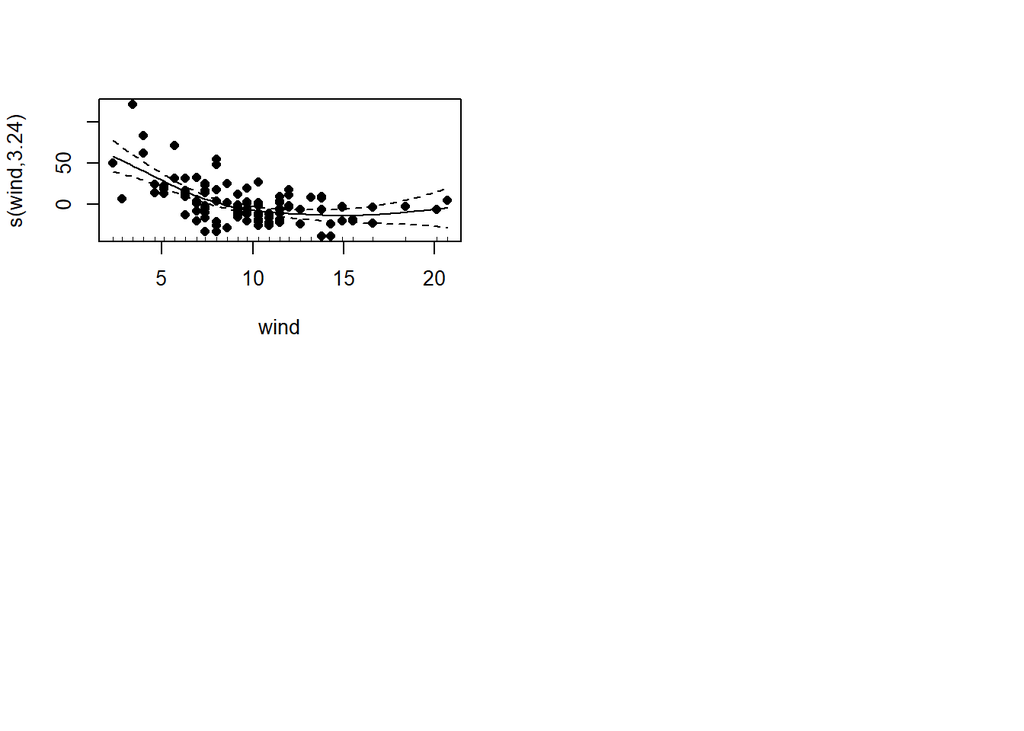

```r
par(mfrow=c(2,2))
plot(m2,residuals=T,pch=16)
```

## We compare the two GAMs to examine significant differences

```r
anova(m1,m2,test="F") # significant; so keep the more complex model
```

```
## Analysis of Deviance Table
##
## Model 1: ozone ~ s(rad) + s(temp) + s(wind)
## Model 2: ozone ~ (temp) + s(wind)
##   Resid. Df Resid. Dev      Df Deviance      F    Pr(>F)
## 1     98.12      30742
## 2    104.95      39863 -6.8295  -9120.1 4.3646 0.0003365 ***
## ---
## Signif. codes:  0 '***' 0.001 '**' 0.01 '*' 0.05 '.' 0.1 ' ' 1
```

```r
str(ozone.data)
```

```
## 'data.frame':    111 obs. of  4 variables:
##  $ rad  : num  190 118 149 313 299 99 19 256 290 274 ...
##  $ temp : num  67 72 74 62 65 59 61 69 66 68 ...
##  $ wind : num  7.4 8 12.6 11.5 8.6 13.8 20.1 9.7 9.2 10.9 ...
##  $ ozone: num  41 36 12 18 23 19 8 16 11 14 ...
```

## radiation should remain in the model since deleting radiation

## caused a highly significant increase in deviance.

## Let’s investigate the possibility of an interaction

## between wind and temperature:

```r
m3 <- gam(ozone~s(temp)+s(wind)+s(rad)+s(wind, temp))
summary(m3)
```

```
##
## Family: gaussian
## Link function: identity
##
## Formula:
## ozone ~ s(temp) + s(wind) + s(rad) + s(wind, temp)
##
## Parametric coefficients:
##             Estimate Std. Error t value Pr(>|t|)
## (Intercept)   42.099      1.361   30.92   <2e-16 ***
## ---
## Signif. codes:  0 '***' 0.001 '**' 0.01 '*' 0.05 '.' 0.1 ' ' 1
##
## Approximate significance of smooth terms:
##                 edf Ref.df     F  p-value
## s(temp)       1.000  1.000 0.000   0.9892
## s(wind)       5.613  6.482 2.492   0.0246 *
## s(rad)        1.389  1.667 5.799   0.0124 *
## s(wind,temp) 18.246 27.000 2.805 6.43e-07 ***
## ---
## Signif. codes:  0 '***' 0.001 '**' 0.01 '*' 0.05 '.' 0.1 ' ' 1
##
## R-sq.(adj) =  0.814   Deviance explained = 85.9%
## GCV = 272.66  Scale est. = 205.72    n = 111
```

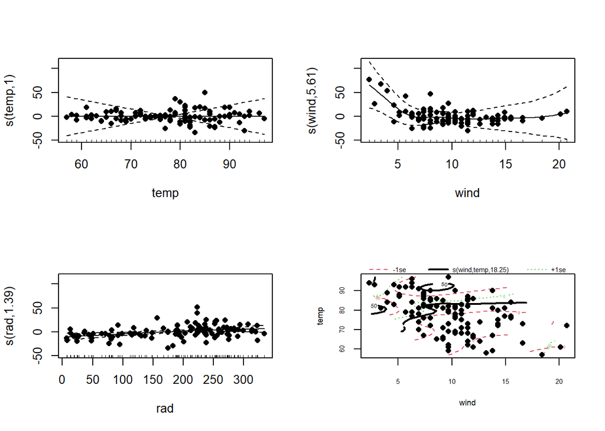

```r
par(mfrow=c(2,2))
plot(m3,residuals=T,pch=16)
```

# Let’s compare m1 and m3:

```r
anova(m1, m3, test="F")
```

```
## Analysis of Deviance Table
##
## Model 1: ozone ~ s(rad) + s(temp) + s(wind)
## Model 2: ozone ~ s(temp) + s(wind) + s(rad) + s(wind, temp)
##   Resid. Df Resid. Dev     Df Deviance      F    Pr(>F)
## 1    98.120      30742
## 2    78.791      17230 19.329    13513 3.3981 6.343e-05 ***
## ---
## Signif. codes:  0 '***' 0.001 '**' 0.01 '*' 0.05 '.' 0.1 ' ' 1
```

## The more complex model with the interaction term is better

## We inspect the fit of model m3 (with interaction term):

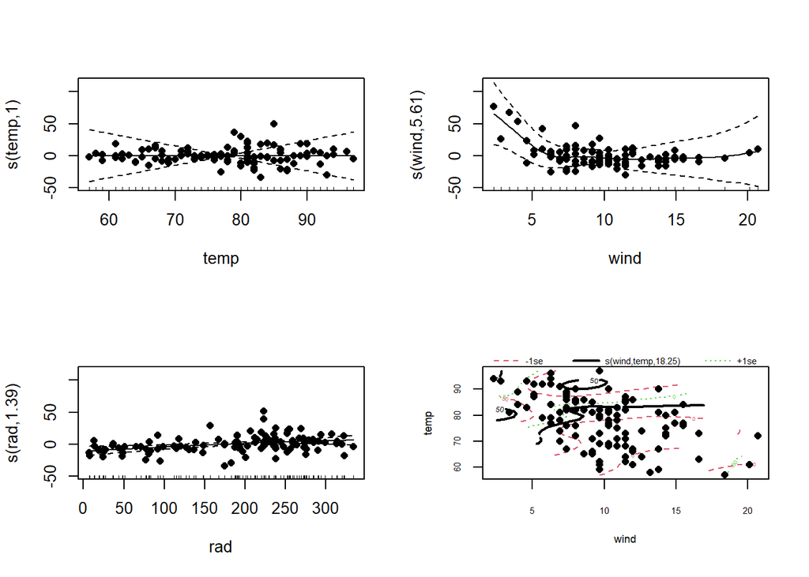

```r
par(mfrow=c(2,2))
plot(m3, residuals=T, pch=16)
```